# Estudios de Informática, Multimedia y Telecomunicaciones

# Tipología y Ciclo de Vida de Datos: PRACTICA2 - Limpieza y Análisis

Autores: Javier López Calderón & José María Cano Hernández

Enero 2021

Esta práctica pretende analizar la Calidad del vino tinto a partir de una serie de atributos. Toda la información relativa al DataSet que se ha utilizado, se ha extraido de la siguiente URL: https://www.kaggle.com/uciml/red-wine-quality-cortez-et-al-2009

# 1 Descripción del dataset. ¿Por qué es importante y qué pregunta/problema pretende responder?

Este Dataset contiene información de los atributos del vino tinto que determinan su nivel de calidad. La variable objetivo (calidad del vino) forma parte del DataSet.

Descripción de las variables contenidas en el fichero:

- fixed acidity: Acidez fija. Cantidad de ácidos fijos o no volátiles.
- volatile acidity: Acidez volátil. Cantidad de ácido acético en el vino.
- citric acid: ácido cítrico. Encontrado en pequeñas cantidad aporta frescura y sabor a los vinos.
- residual sugar: azúcar residual. Cantidad de azúcar presente tras el proceso de fermentación.
- chlorides: Clorides. Cantidad de sal en el vino.
- free sulfur dioxide: dióxido de sulfuro libre. Cantidad.
- total sulfur dioxide: total de dioxido de sulfuro. Cantidad.
- density: densidad. Densidad de agua dependiente del porcentaje de alcohol y contenido en azúcar.
- pH: describe el nivel de acidez o basal que es un vino en la escala de 0 (muy ácido) a 14 (muy básico).
- sulfatos: sulfatos, aditivo del vino que puede contribuir a los niveles de dioxido de sulfuro.
- alcohol: porcentaje de alcohol en el vino.

Variable de Salida: * quality: Calidad. Variable objetivo. Rango de valores de 0 a 10.

La pregunta que pretende responder es determinar la calidad del vino a partir de los atributos que se disponen. Se trata por tanto de un problema supervisado de clasificación en el que se construirán modelos cuyo objetivo sea predecir la calidad del vino tino.

# 2 Integración y selección de los datos de interés a analizar

Cargamos la información del Data Set descargado previamente a fichero winequality-red.csv de la URL mencionada previamente.

```r
# Cargamos los paquetes R que vamos a usar
library(cluster)
library(ggplot2)
library(dplyr)

# Cargamos el juego de datos
dataFile <- read.csv('winequality-red.csv',stringsAsFactors = FALSE, header = TRUE)
filas=dim(dataFile)[1]

# Tipo de variables en fichero cargado.
str(dataFile)
```

```
## 'data.frame':    1599 obs. of  12 variables:
##  $ fixed.acidity       : num  7.4 7.8 7.8 11.2 7.4 7.4 7.9 7.3 7.8 7.5 ...
##  $ volatile.acidity    : num  0.7 0.88 0.76 0.28 0.7 0.66 0.6 0.65 0.58 0.5 ...
##  $ citric.acid         : num  0 0 0.04 0.56 0 0 0.06 0 0.02 0.36 ...
##  $ residual.sugar      : num  1.9 2.6 2.3 1.9 1.9 1.8 1.6 1.2 2 6.1 ...
##  $ chlorides           : num  0.076 0.098 0.092 0.075 0.076 0.075 0.069 0.065 0.073 0.071 ...
##  $ free.sulfur.dioxide : num  11 25 15 17 11 13 15 15 9 17 ...
##  $ total.sulfur.dioxide: num  34 67 54 60 34 40 59 21 18 102 ...
##  $ density             : num  0.998 0.997 0.997 0.998 0.998 ...
##  $ pH                  : num  3.51 3.2 3.26 3.16 3.51 3.51 3.3 3.39 3.36 3.35 ...
##  $ sulphates           : num  0.56 0.68 0.65 0.58 0.56 0.56 0.46 0.47 0.57 0.8 ...
##  $ alcohol             : num  9.4 9.8 9.8 9.8 9.4 9.4 9.4 10 9.5 10.5 ...
##  $ quality             : int  5 5 5 6 5 5 5 7 7 5 ...
```

```r
# Estadísticas de valores vacíos
colSums(is.na(dataFile))
```

```
##        fixed.acidity     volatile.acidity          citric.acid
##                    0                    0                    0
##       residual.sugar            chlorides  free.sulfur.dioxide
##                    0                    0                    0
## total.sulfur.dioxide              density                   pH
##                    0                    0                    0
##            sulphates              alcohol              quality
##                    0                    0                    0
```

```r
colSums(dataFile=="")
```

```
##        fixed.acidity     volatile.acidity          citric.acid
##                    0                    0                    0
##       residual.sugar            chlorides  free.sulfur.dioxide
##                    0                    0                    0
## total.sulfur.dioxide              density                   pH
##                    0                    0                    0
##            sulphates              alcohol              quality
##                    0                    0                    0
```

```r
# Omitimos cualquier row con NA en cualquiera de sus columnas.
dataWine=na.omit(dataFile)
colSums(is.na(dataWine))
```

```
##        fixed.acidity     volatile.acidity          citric.acid
##                    0                    0                    0
##       residual.sugar            chlorides  free.sulfur.dioxide
##                    0                    0                    0
## total.sulfur.dioxide              density                   pH
##                    0                    0                    0
##            sulphates              alcohol              quality
##                    0                    0                    0
```

```r
# Distribución de los diferentes atributos
summary(dataWine)
```

```
##  fixed.acidity   volatile.acidity  citric.acid    residual.sugar
##  Min.   : 4.60   Min.   :0.1200   Min.   :0.000   Min.   : 0.900
##  1st Qu.: 7.10   1st Qu.:0.3900   1st Qu.:0.090   1st Qu.: 1.900
##  Median : 7.90   Median :0.5200   Median :0.260   Median : 2.200
##  Mean   : 8.32   Mean   :0.5278   Mean   :0.271   Mean   : 2.539
##  3rd Qu.: 9.20   3rd Qu.:0.6400   3rd Qu.:0.420   3rd Qu.: 2.600
##  Max.   :15.90   Max.   :1.5800   Max.   :1.000   Max.   :15.500
##    chlorides       free.sulfur.dioxide total.sulfur.dioxide    density
##  Min.   :0.01200   Min.   : 1.00       Min.   :  6.00       Min.   :0.9901
##  1st Qu.:0.07000   1st Qu.: 7.00       1st Qu.: 22.00       1st Qu.:0.9956
##  Median :0.07900   Median :14.00       Median : 38.00       Median :0.9968
##  Mean   :0.08747   Mean   :15.87       Mean   : 46.47       Mean   :0.9967
##  3rd Qu.:0.09000   3rd Qu.:21.00       3rd Qu.: 62.00       3rd Qu.:0.9978
##  Max.   :0.61100   Max.   :72.00       Max.   :289.00       Max.   :1.0037
##        pH          sulphates         alcohol         quality
##  Min.   :2.740   Min.   :0.3300   Min.   : 8.40   Min.   :3.000
##  1st Qu.:3.210   1st Qu.:0.5500   1st Qu.: 9.50   1st Qu.:5.000
##  Median :3.310   Median :0.6200   Median :10.20   Median :6.000
##  Mean   :3.311   Mean   :0.6581   Mean   :10.42   Mean   :5.636
##  3rd Qu.:3.400   3rd Qu.:0.7300   3rd Qu.:11.10   3rd Qu.:6.000
##  Max.   :4.010   Max.   :2.0000   Max.   :14.90   Max.   :8.000
```

A priori, No se detectan nulos ni valores NA. Sin embargo, sí que será necesario analizar en mayor detalle la distribución de los valores de los atributos para identificar outliers o valores extremos.

Examinamos la variable objetivo, analizando la distribución de sus valores.

```r
print("Distribución de Quality")
```

```
## [1] "Distribución de Quality"
```

```r
#Atributo Quality
print("Distribución de Quality")
```

```
## [1] "Distribución de Quality"
```

```r
summary(dataWine$quality)
```

```
##    Min. 1st Qu.  Median    Mean 3rd Qu.    Max.
##   3.000   5.000   6.000   5.636   6.000   8.000
```

```r
table(sort(dataWine$quality))
```

```
##
##   3   4   5   6   7   8
##  10  53 681 638 199  18
```

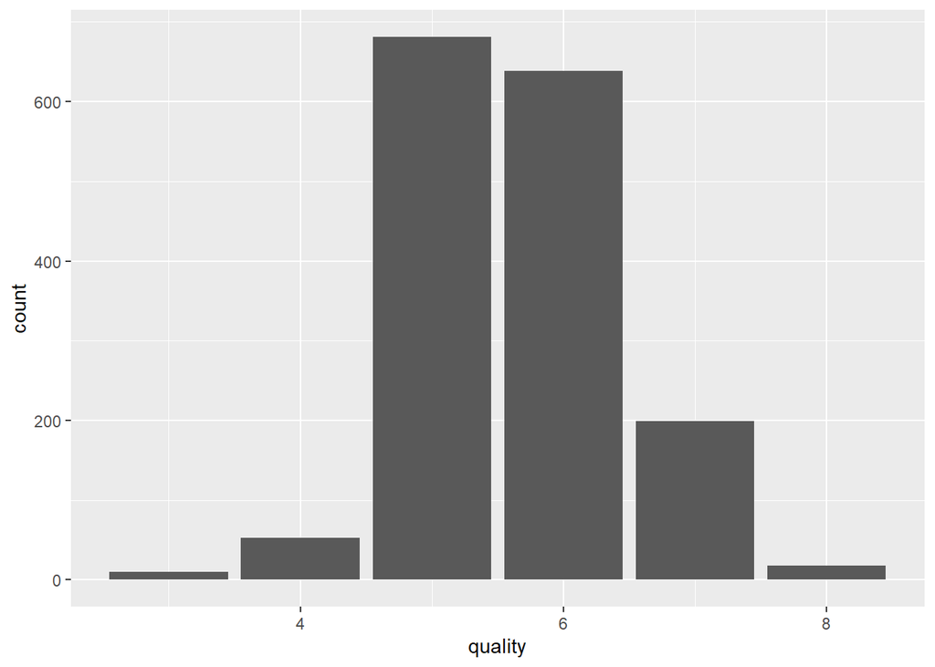

```r
ggplot(data = dataWine[1:filas,],aes(x=quality,fill=))+geom_bar()
```

La gran mayoría de valores corresponden a calidades de 5 y 6.

Discretizamos los valores de la variable objetivo para simplificar, incorporando un nuevo atributo al DataSet denominado “revisionCalidad”:

- Entre 0 y 4, se asigna Calidad Baja.
- Entre 5 y 6, se asigna Calidad Normal.
- Entre 7 y 10, se asigna Calidad Excelente.

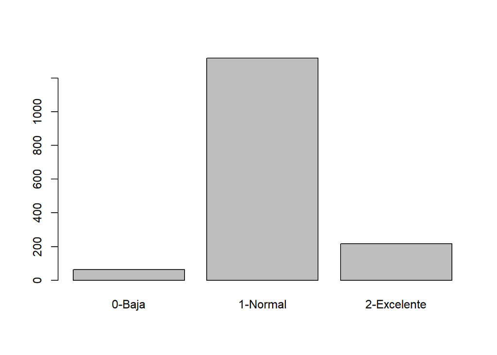

```r
dataWine["revisionCalidad"] <- cut(dataWine$quality, breaks = c(0,4,6,10), labels = c("0-Baja", "1-Normal","2-Excelente"))

# Vemos como se agrupan los datos.
plot(dataWine$revisionCalidad)
```

Distribución de los atributos en base a la variable objetivo Quality

```r
#Distribucion de los Valores en Estudio para conocer donde se concentran sus valores e identificar presencia y relevancia de outliers.
#Atributo fixed.acidity
print("Distribución de fixed.acidity")
```

```
## [1] "Distribución de fixed.acidity"
```

```r
summary(dataWine$fixed.acidity)
```

```
##    Min. 1st Qu.  Median    Mean 3rd Qu.    Max.
##    4.60    7.10    7.90    8.32    9.20   15.90
```

```r
table(sort(dataWine$fixed.acidity))
```

```
##
##  4.6  4.7  4.9    5  5.1  5.2  5.3  5.4  5.5  5.6  5.7  5.8  5.9    6  6.1  6.2
##    1    1    1    6    4    6    4    5    1   14    2    4    9   13   16   20
##  6.3  6.4  6.5  6.6  6.7  6.8  6.9    7  7.1  7.2  7.3  7.4  7.5  7.6  7.7  7.8
##   14   25   17   37   28   46   38   50   57   67   44   44   52   46   49   53
##  7.9    8  8.1  8.2  8.3  8.4  8.5  8.6  8.7  8.8  8.9    9  9.1  9.2  9.3  9.4
##   42   42   26   45   40   26   19   27   24   34   33   26   29   16   22   17
##  9.5  9.6  9.7  9.8  9.9   10 10.1 10.2 10.3 10.4 10.5 10.6 10.7 10.8 10.9   11
##   14   17    9   15   26   23   10   19   11   21   12   14   10   10    8    3
## 11.1 11.2 11.3 11.4 11.5 11.6 11.7 11.8 11.9   12 12.1 12.2 12.3 12.4 12.5 12.6
##    9    5    7    5   13   12    3    3   12    7    1    4    5    4    7    4
## 12.7 12.8 12.9   13 13.2 13.3 13.4 13.5 13.7 13.8   14 14.3   15 15.5 15.6 15.9
##    4    5    2    3    3    3    1    1    2    1    1    1    2    2    2    1
```

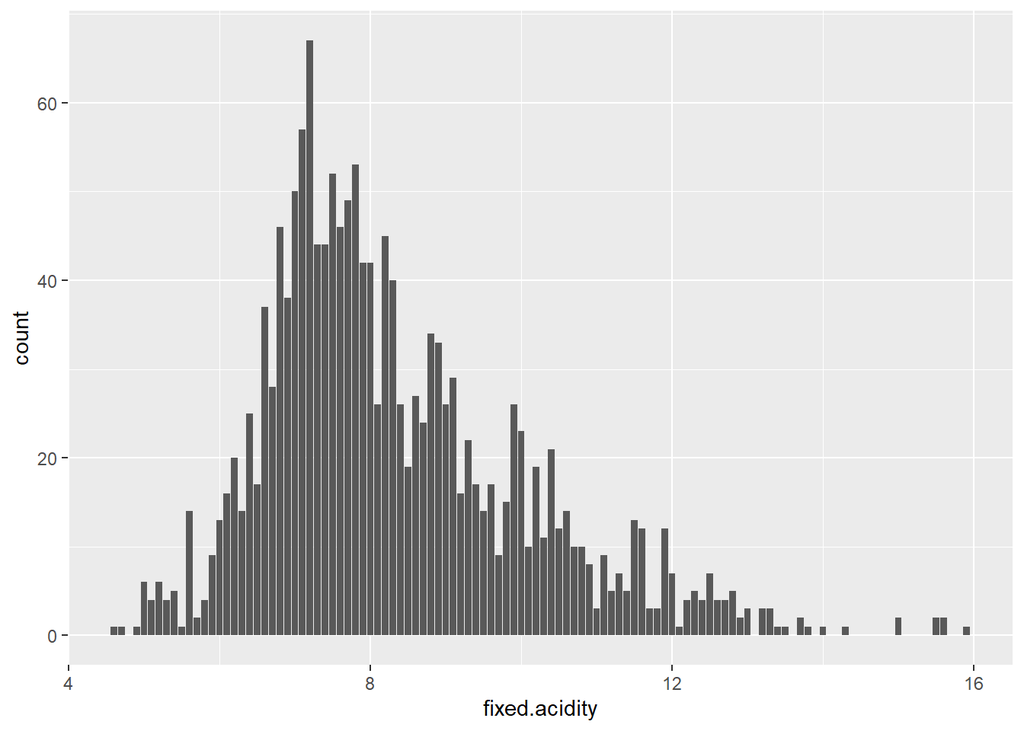

```r
ggplot(data = dataWine[1:filas,],aes(x=fixed.acidity,fill=quality))+geom_bar()
```

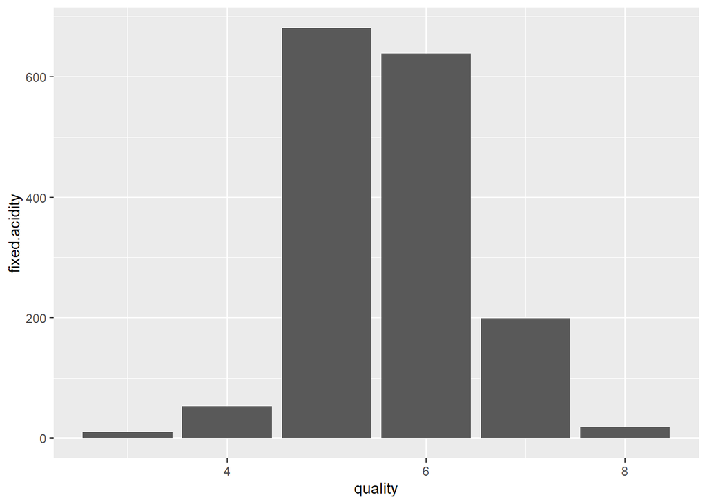

```r
ggplot(data = dataWine[1:filas,],aes(x=quality,fill=fixed.acidity))+geom_bar()+ylab("fixed.acidity")
```

```r
#Atributo volatile.acidity
print("Distribución de volatile.acidity")
```

```
## [1] "Distribución de volatile.acidity"
```

```r
summary(dataWine$volatile.acidity)
```

```
##    Min. 1st Qu.  Median    Mean 3rd Qu.    Max.
##  0.1200  0.3900  0.5200  0.5278  0.6400  1.5800
```

```r
table(sort(dataWine$volatile.acidity))
```

```
##
##  0.12  0.16  0.18  0.19   0.2  0.21  0.22  0.23  0.24  0.25  0.26  0.27  0.28
##     3     2    10     2     3     6     6     5    13     7    16    14    23
##  0.29 0.295   0.3 0.305  0.31 0.315  0.32  0.33  0.34  0.35  0.36 0.365  0.37
##    16     1    16     2    30     2    23    20    30    22    38     2    24
##  0.38  0.39 0.395   0.4  0.41 0.415  0.42  0.43  0.44  0.45  0.46  0.47 0.475
##    35    35     2    37    33     3    31    43    23    22    31    21     2
##  0.48  0.49   0.5  0.51  0.52  0.53  0.54 0.545  0.55  0.56 0.565  0.57 0.575
##    24    35    46    24    33    29    31     5    20    34     1    28     3
##  0.58 0.585  0.59 0.595   0.6 0.605  0.61 0.615  0.62 0.625  0.63 0.635  0.64
##    38     3    39     1    47     3    27     6    24     3    29     9    27
## 0.645  0.65 0.655  0.66 0.665  0.67 0.675  0.68 0.685  0.69 0.695   0.7 0.705
##    12    16     7    26     3    23     3    12    11    23     7    10     6
##  0.71 0.715  0.72 0.725  0.73 0.735  0.74 0.745  0.75 0.755  0.76 0.765  0.77
##     3    12     5     9     6     8    11     5     6     3     5     5     6
## 0.775  0.78 0.785  0.79 0.795   0.8 0.805  0.81 0.815  0.82 0.825  0.83 0.835
##     4    10     8     2     2     3     1     2     3     5     1     4     4
##  0.84 0.845  0.85 0.855  0.86 0.865  0.87 0.875  0.88 0.885  0.89 0.895   0.9
##     8     1     2     3     2     1     4     2     5     5     1     1     3
##  0.91 0.915  0.92 0.935  0.95 0.955  0.96 0.965 0.975  0.98     1 1.005  1.01
##     3     4     1     2     1     1     3     3     1     3     3     1     1
##  1.02 1.025 1.035  1.04  1.07  1.09 1.115  1.13  1.18 1.185  1.24  1.33  1.58
##     4     1     1     3     1     1     1     1     1     1     1     2     1
```

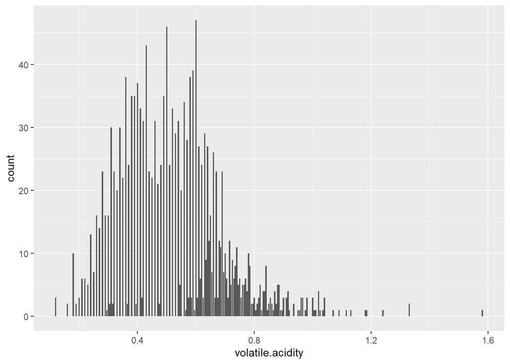

```r
ggplot(data = dataWine[1:filas,],aes(x=volatile.acidity,fill=quality))+geom_bar()
```

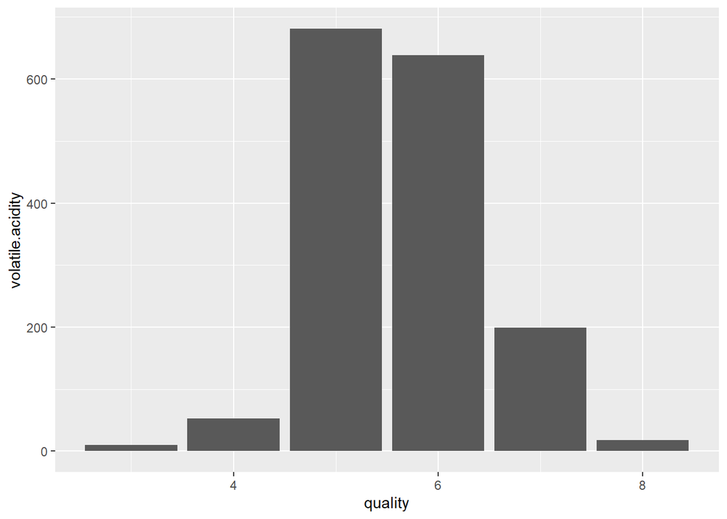

```r
ggplot(data = dataWine[1:filas,],aes(x=quality,fill=volatile.acidity))+geom_bar()+ylab("volatile.acidity")
```

```r
#Atributo citric.acid
print("Distribución de citric.acid")
```

```
## [1] "Distribución de citric.acid"
```

```r
summary(dataWine$citric.acid)
```

```
##    Min. 1st Qu.  Median    Mean 3rd Qu.    Max.
##   0.000   0.090   0.260   0.271   0.420   1.000
```

```r
table(sort(dataWine$citric.acid))
```

```
##
##    0 0.01 0.02 0.03 0.04 0.05 0.06 0.07 0.08 0.09  0.1 0.11 0.12 0.13 0.14 0.15
##  132   33   50   30   29   20   24   22   33   30   35   15   27   18   21   19
## 0.16 0.17 0.18 0.19  0.2 0.21 0.22 0.23 0.24 0.25 0.26 0.27 0.28 0.29  0.3 0.31
##    9   16   22   21   25   33   27   25   51   27   38   20   19   21   30   30
## 0.32 0.33 0.34 0.35 0.36 0.37 0.38 0.39  0.4 0.41 0.42 0.43 0.44 0.45 0.46 0.47
##   32   25   24   13   20   19   14   28   29   16   29   15   23   22   19   18
## 0.48 0.49  0.5 0.51 0.52 0.53 0.54 0.55 0.56 0.57 0.58 0.59  0.6 0.61 0.62 0.63
##   23   68   20   13   17   14   13   12    8    9    9    8    9    2    1   10
## 0.64 0.65 0.66 0.67 0.68 0.69  0.7 0.71 0.72 0.73 0.74 0.75 0.76 0.78 0.79    1
##    9    7   14    2   11    4    2    1    1    3    4    1    3    1    1    1
```

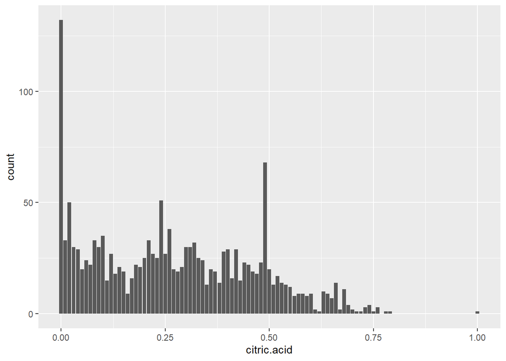

```r
ggplot(data = dataWine[1:filas,],aes(x=citric.acid,fill=quality))+geom_bar()
```

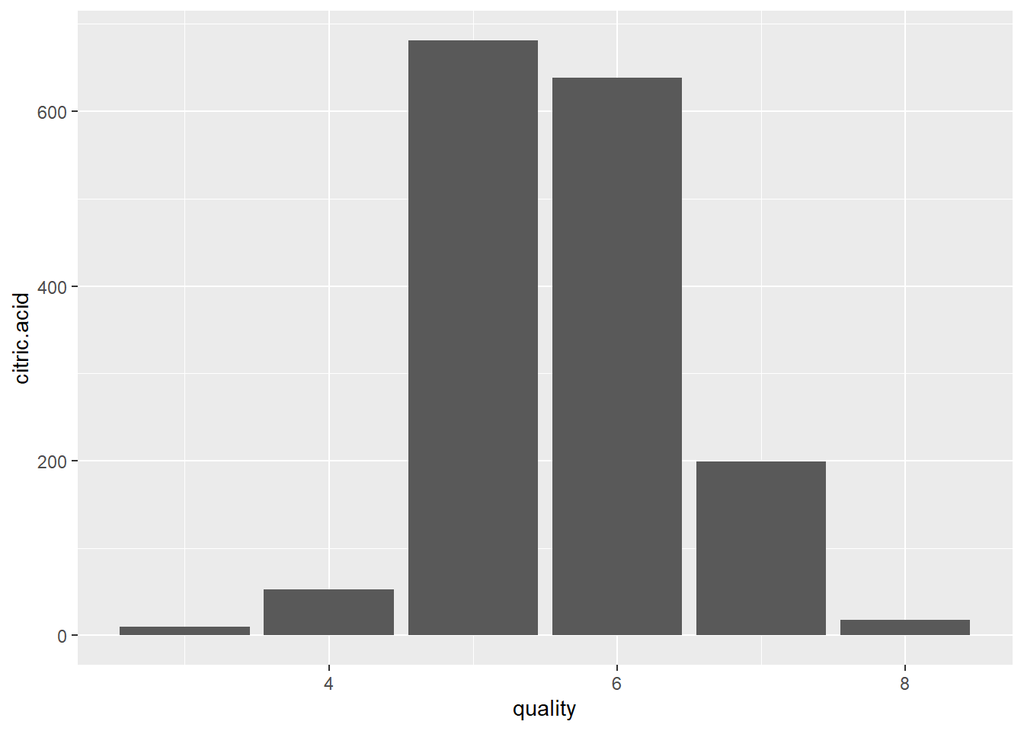

```r
ggplot(data = dataWine[1:filas,],aes(x=quality,fill=citric.acid))+geom_bar()+ylab("citric.acid")
```

```r
#Atributo residual.sugar
print("Distribución de residual.sugar")
```

```
## [1] "Distribución de residual.sugar"
```

```r
summary(dataWine$residual.sugar)
```

```
##    Min. 1st Qu.  Median    Mean 3rd Qu.    Max.
##   0.900   1.900   2.200   2.539   2.600  15.500
```

```r
table(sort(dataWine$residual.sugar))
```

```
##
##  0.9  1.2  1.3  1.4  1.5  1.6 1.65  1.7 1.75  1.8  1.9    2 2.05  2.1 2.15  2.2
##    2    8    5   35   30   58    2   76    2  129  117  156    2  128    2  131
## 2.25  2.3 2.35  2.4  2.5 2.55  2.6 2.65  2.7  2.8 2.85  2.9 2.95    3  3.1  3.2
##    1  109    1   86   84    1   79    1   39   49    1   24    1   25    7   15
##  3.3  3.4 3.45  3.5  3.6 3.65  3.7 3.75  3.8  3.9    4  4.1  4.2 4.25  4.3  4.4
##   11   15    1    2    8    1    4    1    8    6   11    6    5    1    8    4
##  4.5  4.6 4.65  4.7  4.8    5  5.1 5.15  5.2  5.4  5.5  5.6  5.7  5.8  5.9    6
##    4    6    2    1    3    1    5    1    3    1    8    6    1    4    3    4
##  6.1  6.2  6.3  6.4 6.55  6.6  6.7    7  7.2  7.3  7.5  7.8  7.9  8.1  8.3  8.6
##    4    3    2    3    2    2    2    1    1    1    1    2    3    2    3    1
##  8.8  8.9    9 10.7   11 12.9 13.4 13.8 13.9 15.4 15.5
##    2    1    1    1    2    1    1    2    1    2    1
```

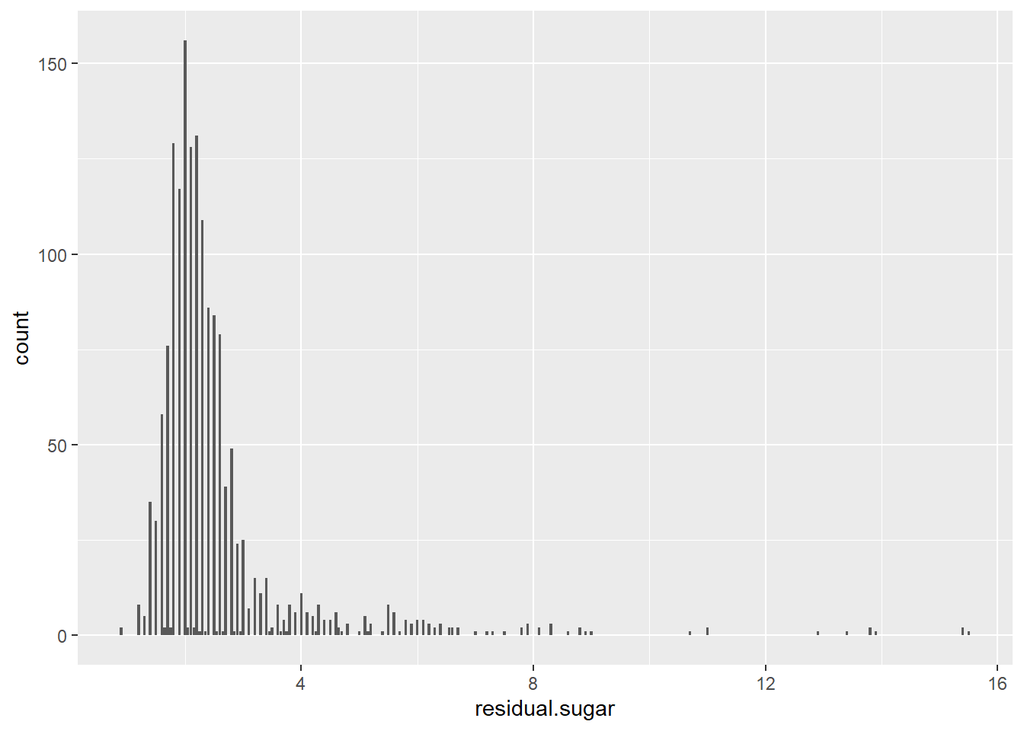

```r
ggplot(data = dataWine[1:filas,],aes(x=residual.sugar,fill=quality))+geom_bar()
```

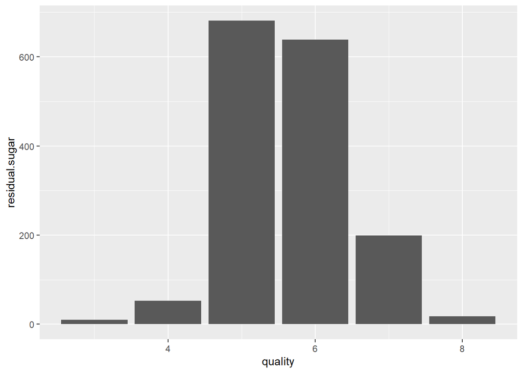

```r
ggplot(data = dataWine[1:filas,],aes(x=quality,fill=residual.sugar))+geom_bar()+ylab("residual.sugar")
```

```r
#Atributo chlorides
print("Distribución de chlorides")
```

```
## [1] "Distribución de chlorides"
```

```r
summary(dataWine$chlorides)
```

```
##    Min. 1st Qu.  Median    Mean 3rd Qu.    Max.
## 0.01200 0.07000 0.07900 0.08747 0.09000 0.61100
```

```r
table(sort(dataWine$chlorides))
```

```
##
## 0.012 0.034 0.038 0.039 0.041 0.042 0.043 0.044 0.045 0.046 0.047 0.048 0.049
##     2     1     2     4     4     3     1     5     4     4     4     8     8
##  0.05 0.051 0.052 0.053 0.054 0.055 0.056 0.057 0.058 0.059  0.06 0.061 0.062
##    12     1    10     5    13     8     9    10    14    17    16    11    24
## 0.063 0.064 0.065 0.066 0.067 0.068 0.069  0.07 0.071 0.072 0.073 0.074 0.075
##    22    20    23    32    27    30    21    35    47    24    35    55    45
## 0.076 0.077 0.078 0.079  0.08 0.081 0.082 0.083 0.084 0.085 0.086 0.087 0.088
##    51    47    51    43    66    40    46    35    49    25    31    25    32
## 0.089  0.09 0.091 0.092 0.093 0.094 0.095 0.096 0.097 0.098 0.099   0.1 0.101
##    25    21    19    22    21    19    23    18    18    12     8    13     5
## 0.102 0.103 0.104 0.105 0.106 0.107 0.108 0.109  0.11 0.111 0.112 0.113 0.114
##    10     7    16     6     8     9     1     3     8     7     6     1    11
## 0.115 0.116 0.117 0.118 0.119  0.12 0.121 0.122 0.123 0.124 0.125 0.126 0.127
##     5     2     4     8     3     3     2     7     6     3     1     1     1
## 0.128 0.132 0.136 0.137 0.143 0.145 0.146 0.147 0.148 0.152 0.153 0.157 0.159
##     1     4     1     1     1     1     1     1     1     2     1     3     1
## 0.161 0.165 0.166 0.168 0.169  0.17 0.171 0.172 0.174 0.176 0.178 0.186  0.19
##     1     1     3     1     1     1     2     1     1     1     2     1     1
## 0.194   0.2 0.205 0.213 0.214 0.216 0.222 0.226  0.23 0.235 0.236 0.241 0.243
##     1     1     2     1     3     1     1     2     1     1     1     1     1
##  0.25 0.263 0.267  0.27 0.332 0.337 0.341 0.343 0.358  0.36 0.368 0.369 0.387
##     1     1     1     1     1     1     1     1     1     1     1     1     1
## 0.401 0.403 0.413 0.414 0.415 0.422 0.464 0.467  0.61 0.611
##     1     1     1     2     3     1     1     1     1     1
```

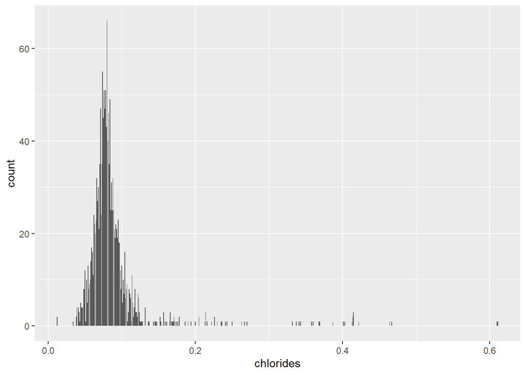

```r
ggplot(data = dataWine[1:filas,],aes(x=chlorides,fill=quality))+geom_bar()
```

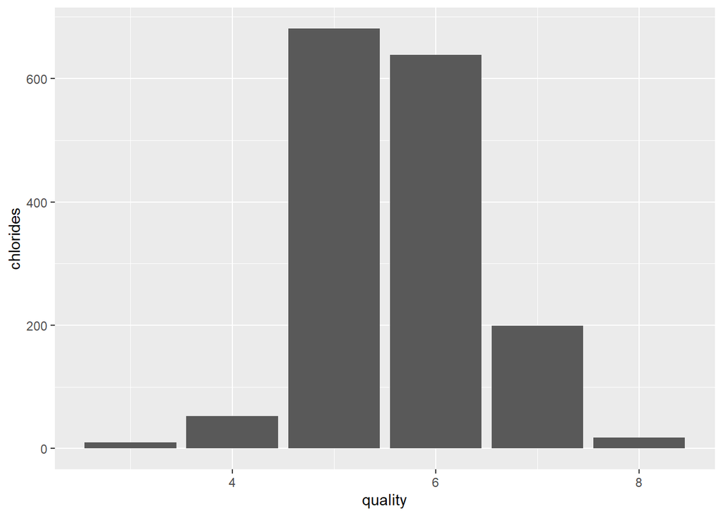

```r
ggplot(data = dataWine[1:filas,],aes(x=quality,fill=chlorides))+geom_bar()+ylab("chlorides")
```

```r
#Atributo free.sulfur.dioxide
print("Distribución de free.sulfur.dioxide")
```

```
## [1] "Distribución de free.sulfur.dioxide"
```

```r
summary(dataWine$free.sulfur.dioxide)
```

```
##    Min. 1st Qu.  Median    Mean 3rd Qu.    Max.
##    1.00    7.00   14.00   15.87   21.00   72.00
```

```r
table(sort(dataWine$free.sulfur.dioxide))
```

```
##
##    1    2    3    4    5  5.5    6    7    8    9   10   11   12   13   14   15
##    3    1   49   41  104    1  138   71   56   62   79   59   75   57   50   78
##   16   17   18   19   20   21   22   23   24   25   26   27   28   29   30   31
##   61   60   46   39   30   41   22   32   34   24   32   29   23   23   16   20
##   32   33   34   35   36   37 37.5   38   39   40 40.5   41   42   43   45   46
##   22   11   18   15   11    3    2    9    5    6    1    7    3    3    3    1
##   47   48   50   51   52   53   54   55   57   66   68   72
##    1    4    2    4    3    1    1    2    1    1    2    1
```

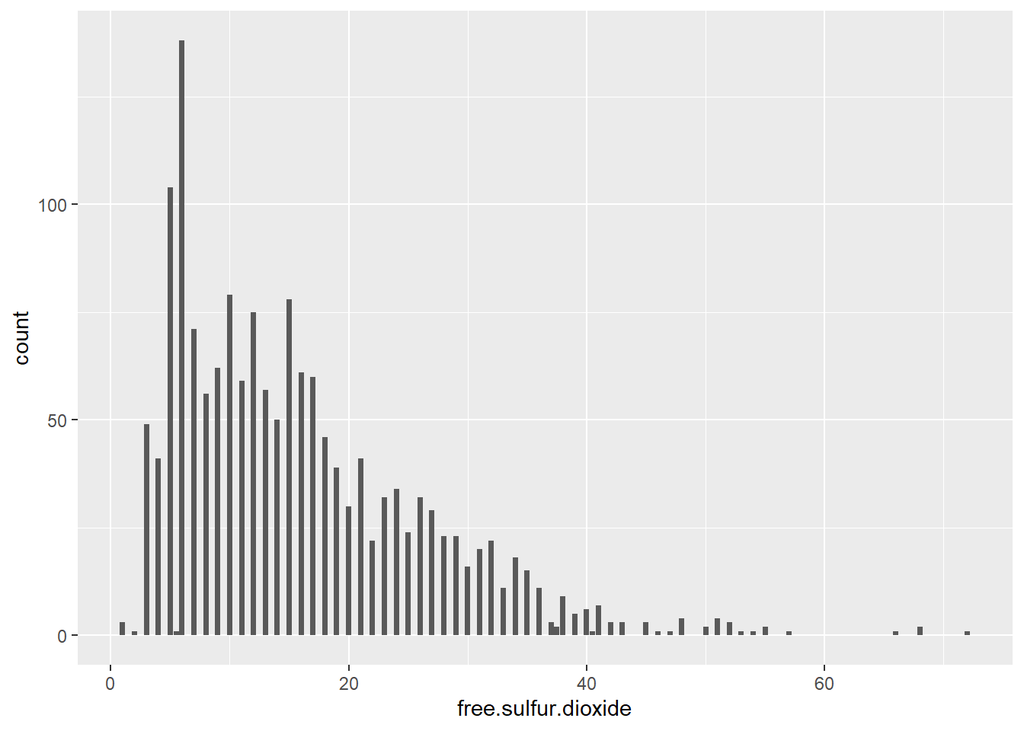

```r
ggplot(data = dataWine[1:filas,],aes(x=free.sulfur.dioxide,fill=quality))+geom_bar()
```

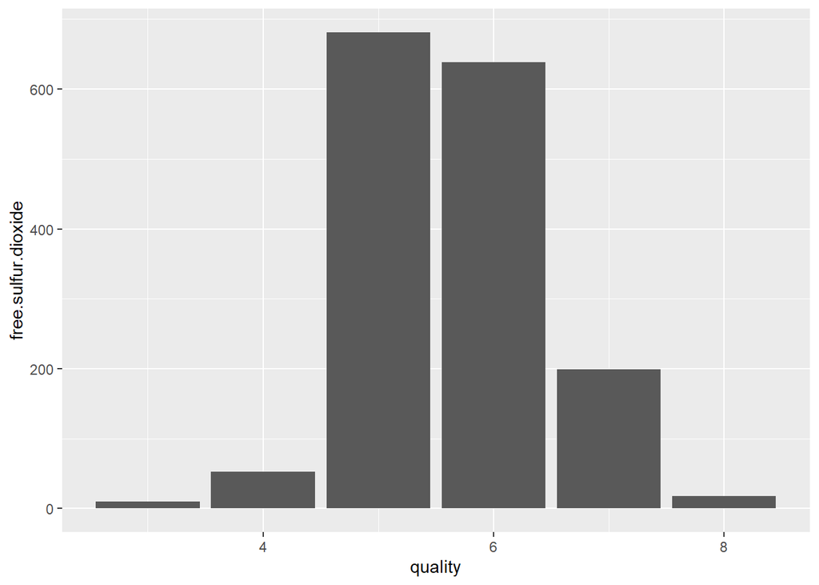

```r
ggplot(data = dataWine[1:filas,],aes(x=quality,fill=free.sulfur.dioxide))+geom_bar()+ylab("free.sulfur.dioxide")
```

```r
#Atributo total.sulfur.dioxide
print("Distribución de total.sulfur.dioxide")
```

```
## [1] "Distribución de total.sulfur.dioxide"
```

```r
summary(dataWine$total.sulfur.dioxide)
```

```
##    Min. 1st Qu.  Median    Mean 3rd Qu.    Max.
##    6.00   22.00   38.00   46.47   62.00  289.00
```

```r
table(sort(dataWine$total.sulfur.dioxide))
```

```
##
##    6    7    8    9   10   11   12   13   14   15   16   17   18   19   20   21
##    3    4   14   14   27   26   29   28   33   35   26   27   35   29   33   25
##   22   23   24   25   26   27   28   29   30   31   32   33   34   35   36   37
##   25   34   36   27   24   30   43   20   14   32   20   17   20   26   12   26
##   38   39   40   41   42   43   44   45   46   47   48   49   50   51   52   53
##   31   16   17   14   26   18   23   20   17   24   21   21   11   11   15   14
##   54   55   56   57   58   59   60   61   62   63   64   65   66   67   68   69
##   20   13   10    6   14    9   18    9    9   13   10   17    9   12   10    8
##   70   71   72   73   74   75   76   77 77.5   78   79   80   81   82   83   84
##    8    7   10    7    8    5    3    8    2    4    5    4    6    4    2    6
##   85   86   87   88   89   90   91   92   93   94   95   96   98   99  100  101
##    9   10    6   14    9    5    7    8    2    8    4    5    7    6    3    4
##  102  103  104  105  106  108  109  110  111  112  113  114  115  116  119  120
##    6    2    5    5    6    3    4    6    3    3    4    2    2    1    7    2
##  121  122  124  125  126  127  128  129  130  131  133  134  135  136  139  140
##    4    3    3    2    1    2    2    3    1    3    3    2    2    2    1    1
##  141  142  143  144  145  147  148  149  151  152  153  155  160  165  278  289
##    3    1    2    3    3    3    2    1    2    1    1    1    1    1    1    1
```

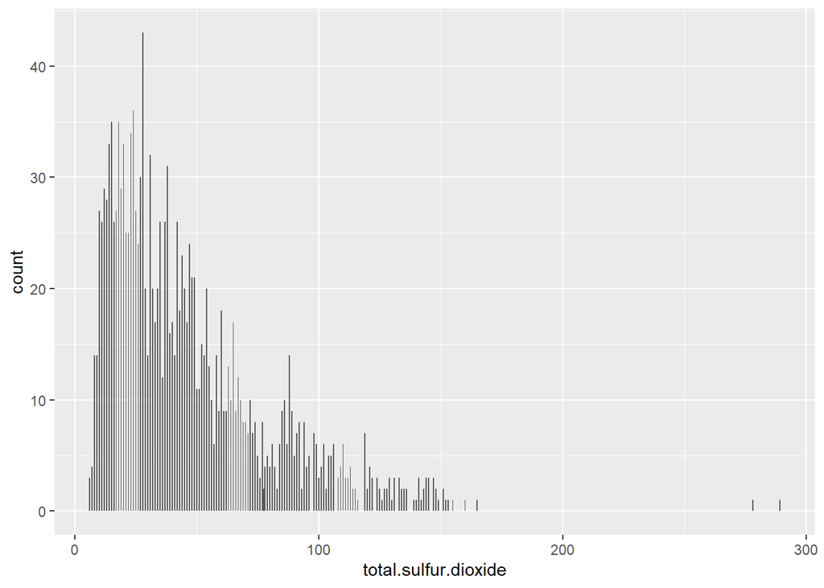

```r
ggplot(data = dataWine[1:filas,],aes(x=total.sulfur.dioxide,fill=quality))+geom_bar()
```

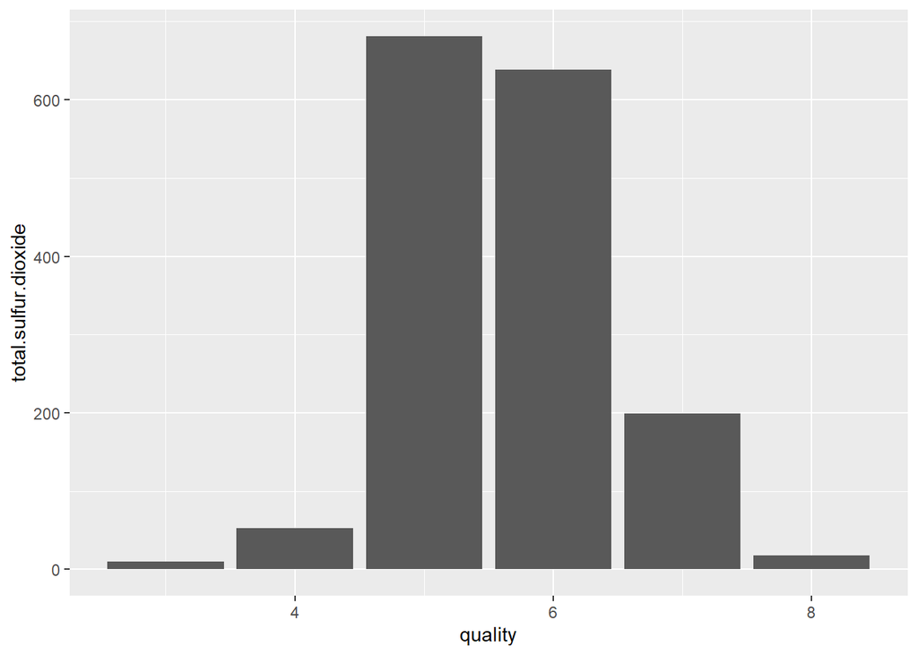

```r
ggplot(data = dataWine[1:filas,],aes(x=quality,fill=total.sulfur.dioxide))+geom_bar()+ylab("total.sulfur.dioxide")
```

```r
#Atributo density
print("Distribución de density")
```

```
## [1] "Distribución de density"
```

```r
summary(dataWine$density)
```

```
##    Min. 1st Qu.  Median    Mean 3rd Qu.    Max.
##  0.9901  0.9956  0.9968  0.9967  0.9978  1.0037
```

```r
table(sort(dataWine$density))
```

```
##
## 0.99007  0.9902 0.99064  0.9908 0.99084  0.9912  0.9915 0.99154 0.99157  0.9916
##       2       1       2       1       1       1       1       1       1       2
## 0.99162  0.9917 0.99182 0.99191  0.9921  0.9922 0.99235 0.99236  0.9924 0.99242
##       1       1       2       1       1       2       1       1       3       2
## 0.99252 0.99256 0.99258 0.99264  0.9927  0.9928 0.99286  0.9929 0.99292 0.99294
##       1       1       3       1       1       2       1       1       1       2
## 0.99306 0.99314 0.99316 0.99318  0.9932 0.99322 0.99323 0.99328  0.9933 0.99331
##       1       1       2       1       1       1       1       1       1       2
## 0.99332 0.99334 0.99336  0.9934 0.99341 0.99344 0.99346 0.99348  0.9935 0.99352
##       1       1       1       4       1       1       3       1       1       2
## 0.99354 0.99356 0.99357 0.99358  0.9936 0.99362 0.99364  0.9937 0.99371 0.99374
##       2       4       1       3       2       2       1       2       2       2
## 0.99376 0.99378 0.99379  0.9938 0.99384 0.99385 0.99386 0.99387 0.99388 0.99392
##       3       3       1       1       1       1       1       1       2       2
## 0.99394 0.99395 0.99396 0.99397   0.994 0.99402 0.99408  0.9941 0.99414 0.99416
##       1       1       3       1       2       4       3       1       2       1
## 0.99417 0.99418 0.99419  0.9942 0.99425 0.99426 0.99428  0.9943 0.99434 0.99437
##       1       2       2       3       1       1       1       2       1       1
## 0.99438 0.99439  0.9944 0.99444 0.99448 0.99451 0.99454 0.99456 0.99458 0.99459
##       5       1       3       4       4       1       1       1       4       1
##  0.9946 0.99462 0.99464 0.99467 0.99468  0.9947 0.99471 0.99472 0.99473 0.99474
##       5       2       2       2       1       6       3       3       1       1
## 0.99476 0.99478 0.99479  0.9948 0.99483 0.99484 0.99486 0.99488 0.99489  0.9949
##       3       2       1       9       1       3       1       4       3       4
## 0.99491 0.99492 0.99494 0.99495 0.99496 0.99498 0.99499   0.995 0.99501 0.99502
##       1       2       4       2       1       5       1      10       1       2
## 0.99504 0.99506 0.99508 0.99509  0.9951 0.99512 0.99514 0.99516 0.99517 0.99518
##       2       1       3       1       4       2       5       6       1       3
## 0.99519  0.9952 0.99521 0.99522 0.99523 0.99524 0.99525 0.99526 0.99528 0.99529
##       1       9       1       4       1       4       2       2       3       1
##  0.9953 0.99531 0.99532 0.99533 0.99534 0.99536 0.99538  0.9954 0.99541 0.99542
##       4       2       1       1       6       2      11       4       1       1
## 0.99543 0.99544 0.99545 0.99546 0.99547 0.99549  0.9955 0.99551 0.99552 0.99553
##       2       1       3       7       2       2      14       3       5       1
## 0.99554 0.99555 0.99556 0.99557 0.99558  0.9956 0.99562 0.99564 0.99565 0.99566
##       3       1       2       3       3      14       4       2       3       4
## 0.99568 0.99569  0.9957 0.99572 0.99573 0.99574 0.99575 0.99576 0.99577 0.99578
##       4       1       6       9       1       2       2       5       3       3
##  0.9958 0.99581 0.99582 0.99584 0.99585 0.99586 0.99587 0.99588 0.99589  0.9959
```

[output cut: 34 more lines]

```
##       2       2       3      23       1       1       3       2       9       1
## 0.99834 0.99836  0.9984 0.99842 0.99845  0.9985 0.99852 0.99854 0.99855 0.99859
##       1       2      20       2       1       3       1       1       2       1
##  0.9986 0.99864 0.99865  0.9987 0.99878  0.9988 0.99888  0.9989 0.99892   0.999
##      19       1       2      12       1      20       2       2       3       8
## 0.99901  0.9991 0.99914 0.99915 0.99918  0.9992 0.99922 0.99925  0.9993 0.99935
##       1      10       3       1       1       7       1       1       4       1
## 0.99938 0.99939  0.9994  0.9995  0.9996 0.99965  0.9997 0.99974 0.99975 0.99976
##       1       1      24       1      12       1       8       1       1       1
##  0.9998  0.9999       1 1.00005  1.0001 1.00012 1.00015  1.0002 1.00024 1.00025
##      10       1      10       2       4       1       2      10       1       1
##  1.0003  1.0004  1.0006  1.0008   1.001  1.0014  1.0015  1.0018  1.0021  1.0022
##       2       9       6       3       6       6       2       1       2       2
## 1.00242  1.0026 1.00289 1.00315  1.0032 1.00369
##       2       2       1       3       1       2
```

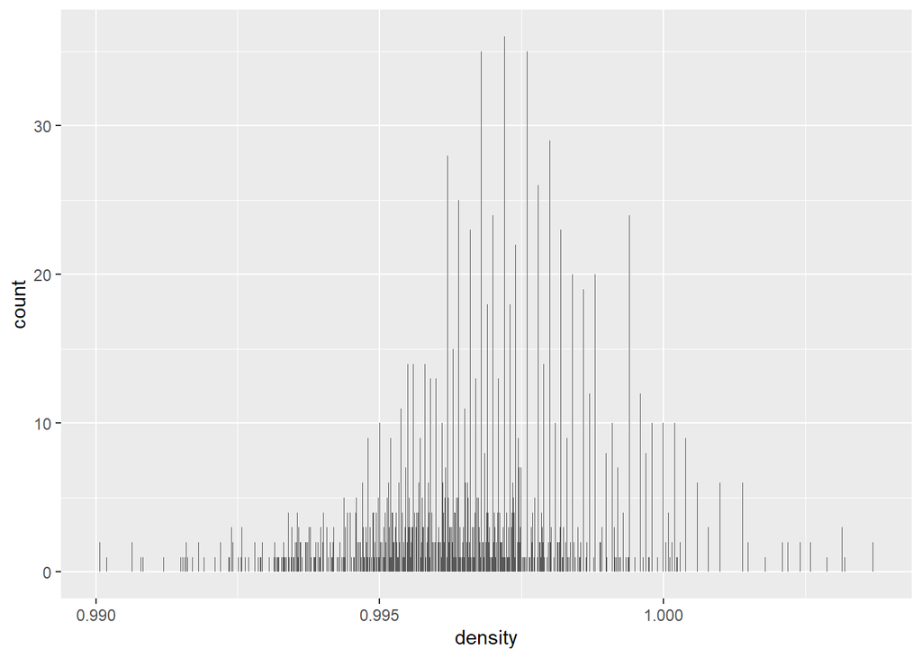

```r
ggplot(data = dataWine[1:filas,],aes(x=density,fill=quality))+geom_bar()
```

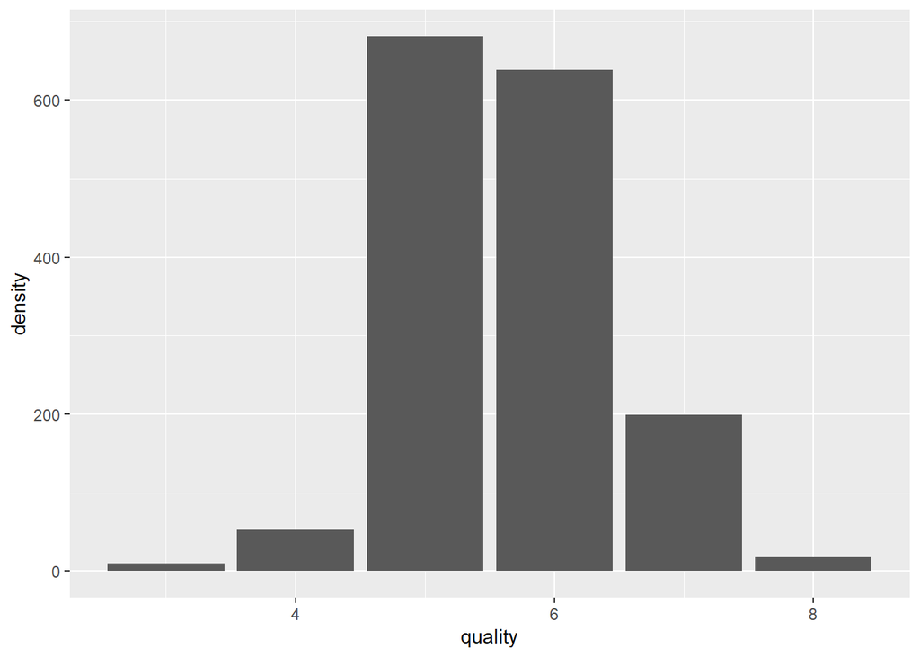

```r
ggplot(data = dataWine[1:filas,],aes(x=quality,fill=density))+geom_bar()+ylab("density")
```

```r
#Atributo pH
print("Distribución de pH")
```

```
## [1] "Distribución de pH"
```

```r
summary(dataWine$pH)
```

```
##    Min. 1st Qu.  Median    Mean 3rd Qu.    Max.
##   2.740   3.210   3.310   3.311   3.400   4.010
```

```r
table(sort(dataWine$pH))
```

```
##
## 2.74 2.86 2.87 2.88 2.89  2.9 2.92 2.93 2.94 2.95 2.98 2.99    3 3.01 3.02 3.03
##    1    1    1    2    4    1    4    3    4    1    5    2    6    5    8    6
## 3.04 3.05 3.06 3.07 3.08 3.09  3.1 3.11 3.12 3.13 3.14 3.15 3.16 3.17 3.18 3.19
##   10    8   10   11   11   11   19    9   20   13   21   34   36   27   30   25
##  3.2 3.21 3.22 3.23 3.24 3.25 3.26 3.27 3.28 3.29  3.3 3.31 3.32 3.33 3.34 3.35
##   39   36   39   32   29   26   53   35   42   46   57   39   45   37   43   39
## 3.36 3.37 3.38 3.39  3.4 3.41 3.42 3.43 3.44 3.45 3.46 3.47 3.48 3.49  3.5 3.51
##   56   37   48   48   37   34   33   17   29   20   22   21   19   10   14   15
## 3.52 3.53 3.54 3.55 3.56 3.57 3.58 3.59  3.6 3.61 3.62 3.63 3.66 3.67 3.68 3.69
##   18   17   16    8   11   10   10    8    7    8    4    3    4    3    5    4
##  3.7 3.71 3.72 3.74 3.75 3.78 3.85  3.9 4.01
##    1    4    3    1    1    2    1    2    2
```

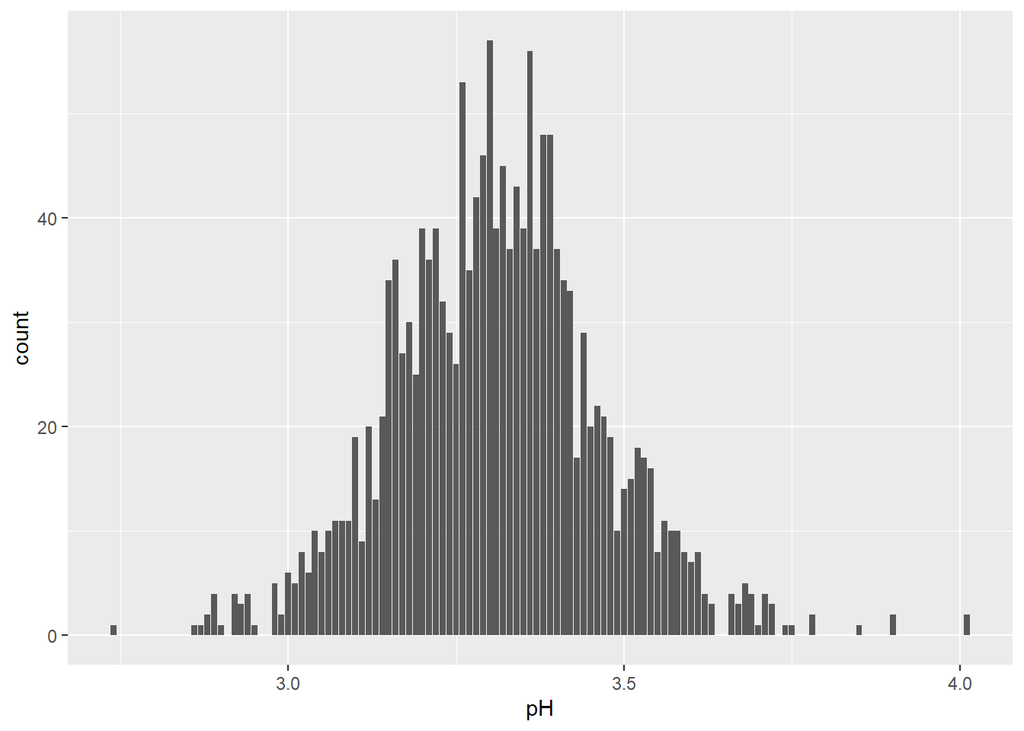

```r
ggplot(data = dataWine[1:filas,],aes(x=pH,fill=quality))+geom_bar()
```

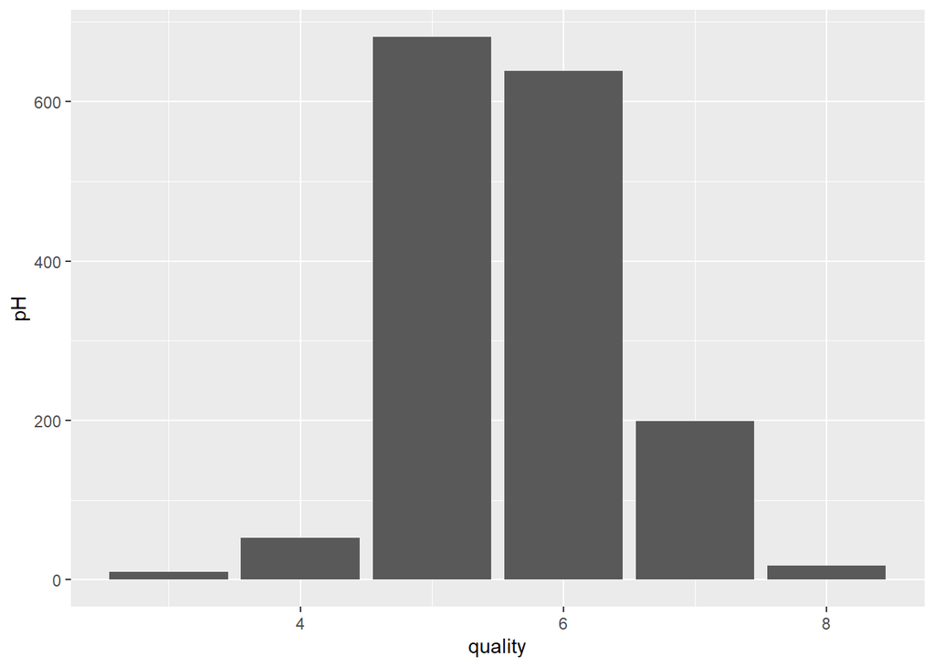

```r
ggplot(data = dataWine[1:filas,],aes(x=quality,fill=pH))+geom_bar()+ylab("pH")
```

```r
#Atributo sulphates
print("Distribución de Sulphates")
```

```
## [1] "Distribución de Sulphates"
```

```r
summary(dataWine$sulphates)
```

```
##    Min. 1st Qu.  Median    Mean 3rd Qu.    Max.
##  0.3300  0.5500  0.6200  0.6581  0.7300  2.0000
```

```r
table(sort(dataWine$sulphates))
```

```
##
## 0.33 0.37 0.39  0.4 0.42 0.43 0.44 0.45 0.46 0.47 0.48 0.49  0.5 0.51 0.52 0.53
##    1    2    6    4    5    8   16   12   18   19   29   31   27   26   47   51
## 0.54 0.55 0.56 0.57 0.58 0.59  0.6 0.61 0.62 0.63 0.64 0.65 0.66 0.67 0.68 0.69
##   68   50   60   55   68   51   69   45   61   48   46   41   42   36   35   23
##  0.7 0.71 0.72 0.73 0.74 0.75 0.76 0.77 0.78 0.79  0.8 0.81 0.82 0.83 0.84 0.85
##   33   26   28   26   26   20   25   26   23   18   19   15   22   15   13   14
## 0.86 0.87 0.88 0.89  0.9 0.91 0.92 0.93 0.94 0.95 0.96 0.97 0.98 0.99    1 1.01
##   13   13    7    7    8    8    5   10    4    2    3    6    2    3    1    1
## 1.02 1.03 1.04 1.05 1.06 1.07 1.08 1.09  1.1 1.11 1.12 1.13 1.14 1.15 1.16 1.17
##    3    2    2    3    4    2    3    1    2    1    1    2    2    1    1    5
## 1.18  1.2 1.22 1.26 1.28 1.31 1.33 1.34 1.36 1.56 1.59 1.61 1.62 1.95 1.98    2
##    3    1    1    1    2    1    1    1    3    1    1    1    1    2    1    1
```

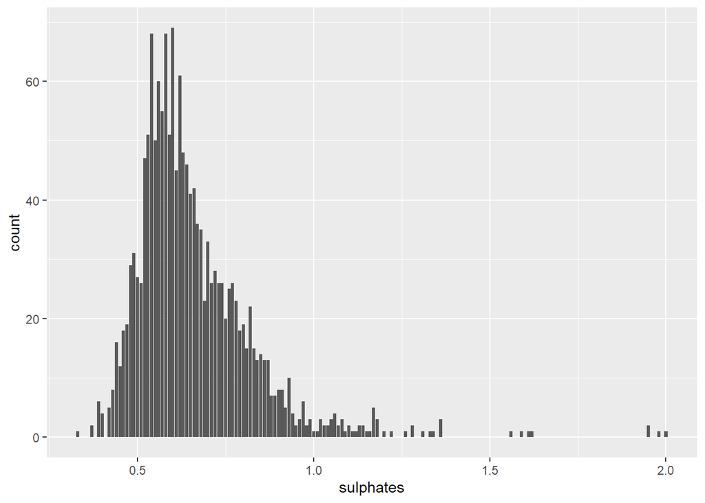

```r
ggplot(data = dataWine[1:filas,],aes(x=sulphates,fill=quality))+geom_bar()
```

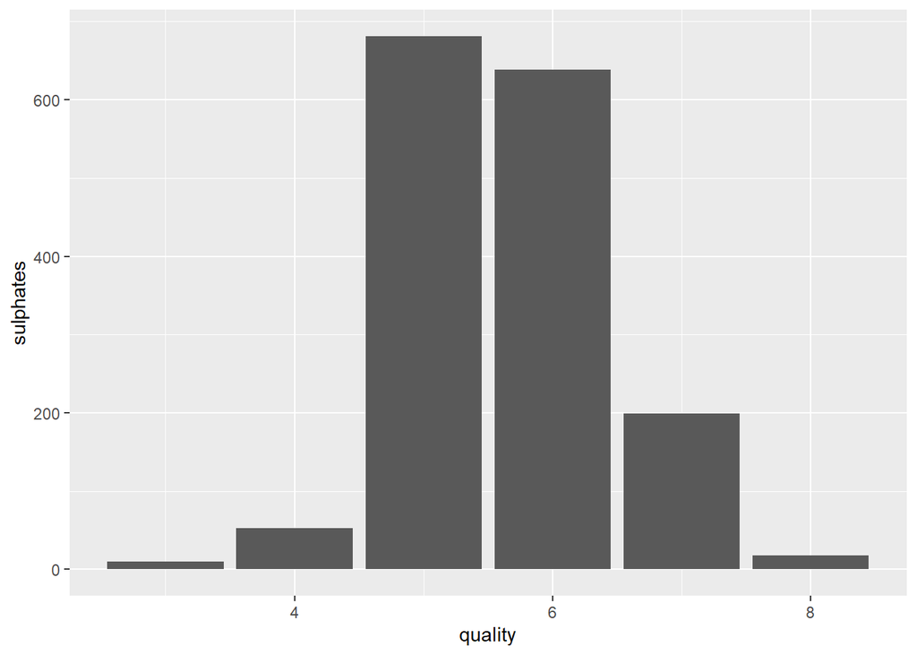

```r
ggplot(data = dataWine[1:filas,],aes(x=quality,fill=sulphates))+geom_bar()+ylab("sulphates")
```

```r
#Atributo alcohol
print("Distribución de alcohol")
```

```
## [1] "Distribución de alcohol"
```

```r
summary(dataWine$alcohol)
```

```
##    Min. 1st Qu.  Median    Mean 3rd Qu.    Max.
##    8.40    9.50   10.20   10.42   11.10   14.90
```

```r
table(sort(dataWine$alcohol))
```

```
##
##              8.4              8.5              8.7              8.8
##                2                1                2                2
##                9             9.05              9.1              9.2
##               30                1               23               72
## 9.23333333333333             9.25              9.3              9.4
##                1                1               59              103
##              9.5             9.55 9.56666666666667              9.6
##              139                2                1               59
##              9.7              9.8              9.9             9.95
##               54               78               49                1
##               10 10.0333333333333             10.1             10.2
##               67                2               47               46
##             10.3             10.4             10.5            10.55
##               33               41               67                2
##             10.6             10.7            10.75             10.8
##               28               27                1               42
##             10.9               11 11.0666666666667             11.1
##               49               59                1               27
##             11.2             11.3             11.4             11.5
##               36               32               32               30
##             11.6             11.7             11.8             11.9
##               15               23               29               20
##            11.95               12             12.1             12.2
##                1               21               13               12
##             12.3             12.4             12.5             12.6
##               12               13               21                6
##             12.7             12.8             12.9               13
##                9               17                9                6
##             13.1             13.2             13.3             13.4
##                2                1                3                3
##             13.5 13.5666666666667             13.6               14
##                1                1                4                7
##             14.9
##                1
```

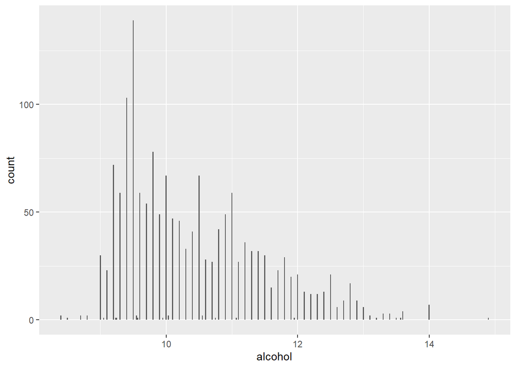

```r
ggplot(data = dataWine[1:filas,],aes(x=alcohol,fill=quality))+geom_bar()
```

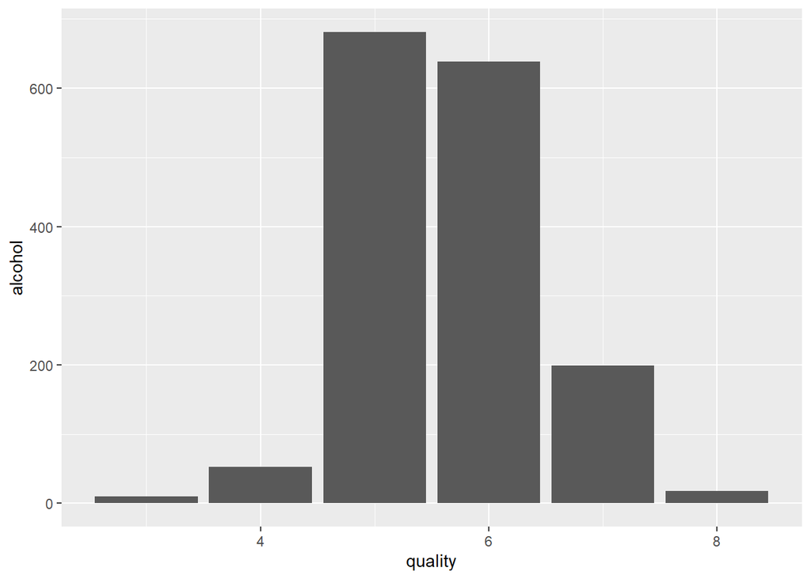

```r
ggplot(data = dataWine[1:filas,],aes(x=quality,fill=alcohol))+geom_bar()+ylab("alcohol")
```

Distribución de los atributos en base a la nueva variable objetivo revisionCalidad.

```r
#Distribucion de los Valores en Estudio para conocer donde se concentran sus valores e identificar presencia y relevancia de outliers.
#Atributo fixed.acidity
print("Distribución de fixed.acidity")
```

```
## [1] "Distribución de fixed.acidity"
```

```r
summary(dataWine$fixed.acidity)
```

```
##    Min. 1st Qu.  Median    Mean 3rd Qu.    Max.
##    4.60    7.10    7.90    8.32    9.20   15.90
```

```r
table(sort(dataWine$fixed.acidity))
```

```
##
##  4.6  4.7  4.9    5  5.1  5.2  5.3  5.4  5.5  5.6  5.7  5.8  5.9    6  6.1  6.2
##    1    1    1    6    4    6    4    5    1   14    2    4    9   13   16   20
##  6.3  6.4  6.5  6.6  6.7  6.8  6.9    7  7.1  7.2  7.3  7.4  7.5  7.6  7.7  7.8
##   14   25   17   37   28   46   38   50   57   67   44   44   52   46   49   53
##  7.9    8  8.1  8.2  8.3  8.4  8.5  8.6  8.7  8.8  8.9    9  9.1  9.2  9.3  9.4
##   42   42   26   45   40   26   19   27   24   34   33   26   29   16   22   17
##  9.5  9.6  9.7  9.8  9.9   10 10.1 10.2 10.3 10.4 10.5 10.6 10.7 10.8 10.9   11
##   14   17    9   15   26   23   10   19   11   21   12   14   10   10    8    3
## 11.1 11.2 11.3 11.4 11.5 11.6 11.7 11.8 11.9   12 12.1 12.2 12.3 12.4 12.5 12.6
##    9    5    7    5   13   12    3    3   12    7    1    4    5    4    7    4
## 12.7 12.8 12.9   13 13.2 13.3 13.4 13.5 13.7 13.8   14 14.3   15 15.5 15.6 15.9
##    4    5    2    3    3    3    1    1    2    1    1    1    2    2    2    1
```

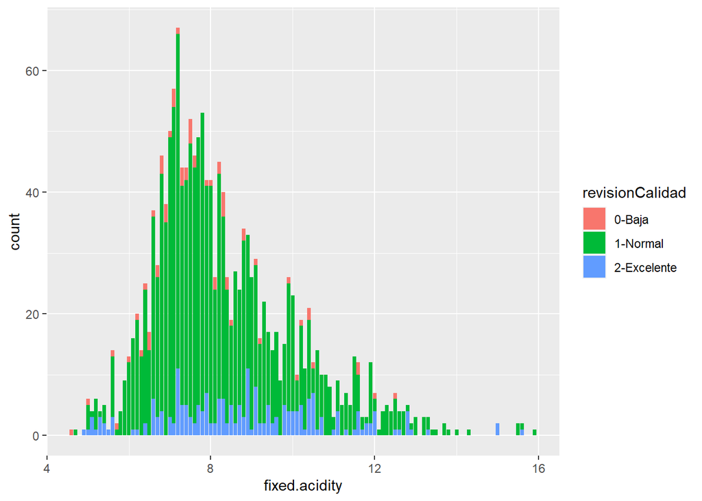

```r
ggplot(data = dataWine[1:filas,],aes(x=fixed.acidity,fill=revisionCalidad))+geom_bar()
```

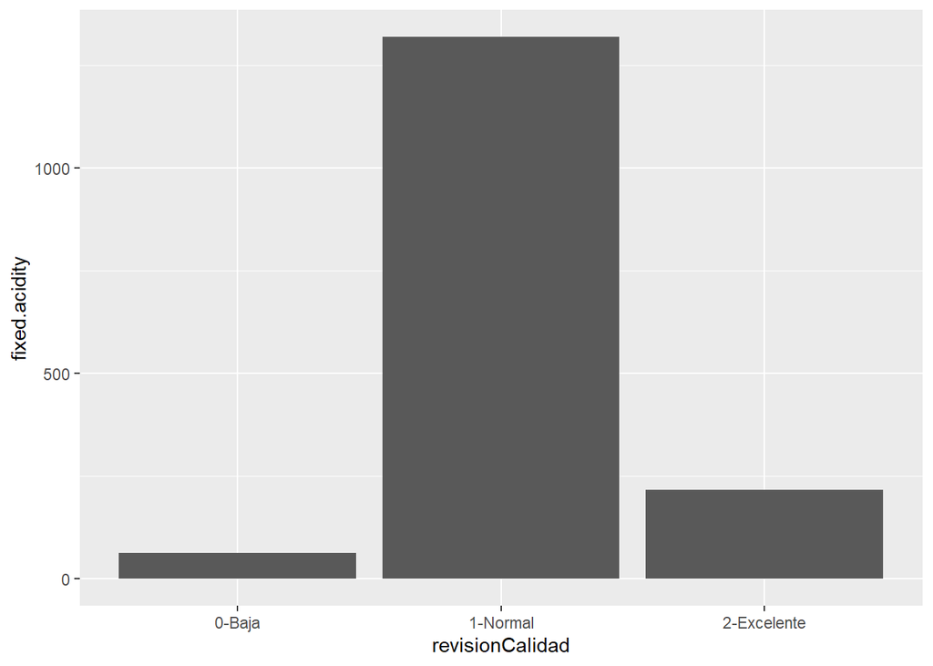

```r
ggplot(data = dataWine[1:filas,],aes(x=revisionCalidad,fill=fixed.acidity))+geom_bar()+ylab("fixed.acidity")
```

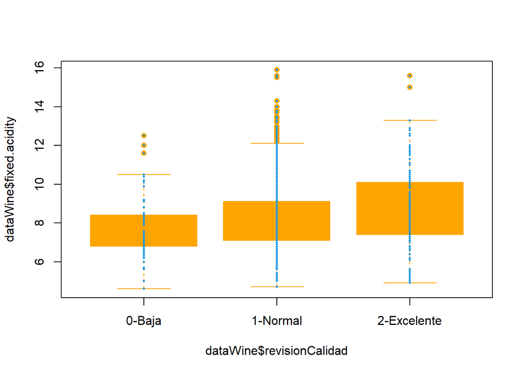

```r
boxplot(dataWine$fixed.acidity ~ dataWine$revisionCalidad,
        col = "orange",
        border = "orange",
        pch = 16)

points(dataWine$revisionCalidad, dataWine$fixed.acidity,
       col = "#1b98e0",
       pch = 16,
       cex = 0.4)
```

```r
#Atributo volatile.acidity
print("Distribución de volatile.acidity")
```

```
## [1] "Distribución de volatile.acidity"
```

```r
summary(dataWine$volatile.acidity)
```

```
##    Min. 1st Qu.  Median    Mean 3rd Qu.    Max.
##  0.1200  0.3900  0.5200  0.5278  0.6400  1.5800
```

```r
table(sort(dataWine$volatile.acidity))
```

```
##
##  0.12  0.16  0.18  0.19   0.2  0.21  0.22  0.23  0.24  0.25  0.26  0.27  0.28
##     3     2    10     2     3     6     6     5    13     7    16    14    23
##  0.29 0.295   0.3 0.305  0.31 0.315  0.32  0.33  0.34  0.35  0.36 0.365  0.37
##    16     1    16     2    30     2    23    20    30    22    38     2    24
##  0.38  0.39 0.395   0.4  0.41 0.415  0.42  0.43  0.44  0.45  0.46  0.47 0.475
##    35    35     2    37    33     3    31    43    23    22    31    21     2
##  0.48  0.49   0.5  0.51  0.52  0.53  0.54 0.545  0.55  0.56 0.565  0.57 0.575
##    24    35    46    24    33    29    31     5    20    34     1    28     3
##  0.58 0.585  0.59 0.595   0.6 0.605  0.61 0.615  0.62 0.625  0.63 0.635  0.64
##    38     3    39     1    47     3    27     6    24     3    29     9    27
## 0.645  0.65 0.655  0.66 0.665  0.67 0.675  0.68 0.685  0.69 0.695   0.7 0.705
##    12    16     7    26     3    23     3    12    11    23     7    10     6
##  0.71 0.715  0.72 0.725  0.73 0.735  0.74 0.745  0.75 0.755  0.76 0.765  0.77
##     3    12     5     9     6     8    11     5     6     3     5     5     6
## 0.775  0.78 0.785  0.79 0.795   0.8 0.805  0.81 0.815  0.82 0.825  0.83 0.835
##     4    10     8     2     2     3     1     2     3     5     1     4     4
##  0.84 0.845  0.85 0.855  0.86 0.865  0.87 0.875  0.88 0.885  0.89 0.895   0.9
##     8     1     2     3     2     1     4     2     5     5     1     1     3
##  0.91 0.915  0.92 0.935  0.95 0.955  0.96 0.965 0.975  0.98     1 1.005  1.01
##     3     4     1     2     1     1     3     3     1     3     3     1     1
##  1.02 1.025 1.035  1.04  1.07  1.09 1.115  1.13  1.18 1.185  1.24  1.33  1.58
##     4     1     1     3     1     1     1     1     1     1     1     2     1
```

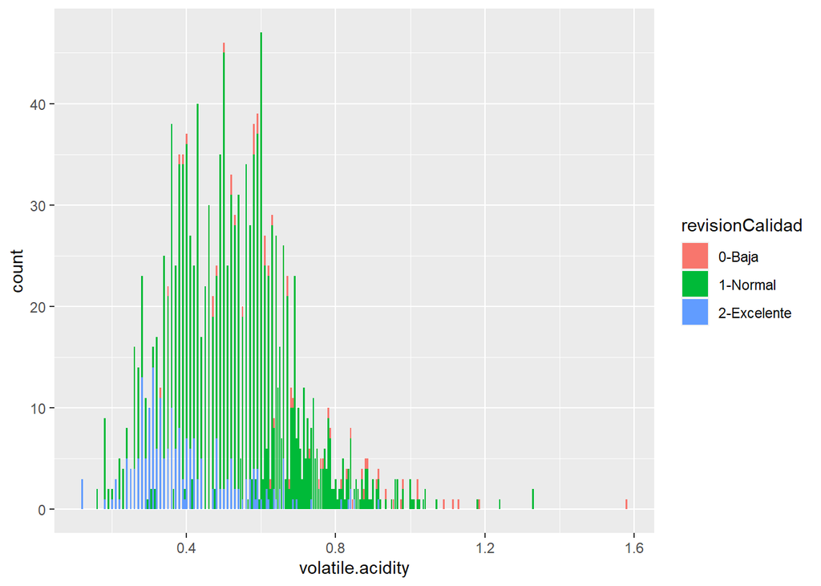

```r
ggplot(data = dataWine[1:filas,],aes(x=volatile.acidity,fill=revisionCalidad))+geom_bar()
```

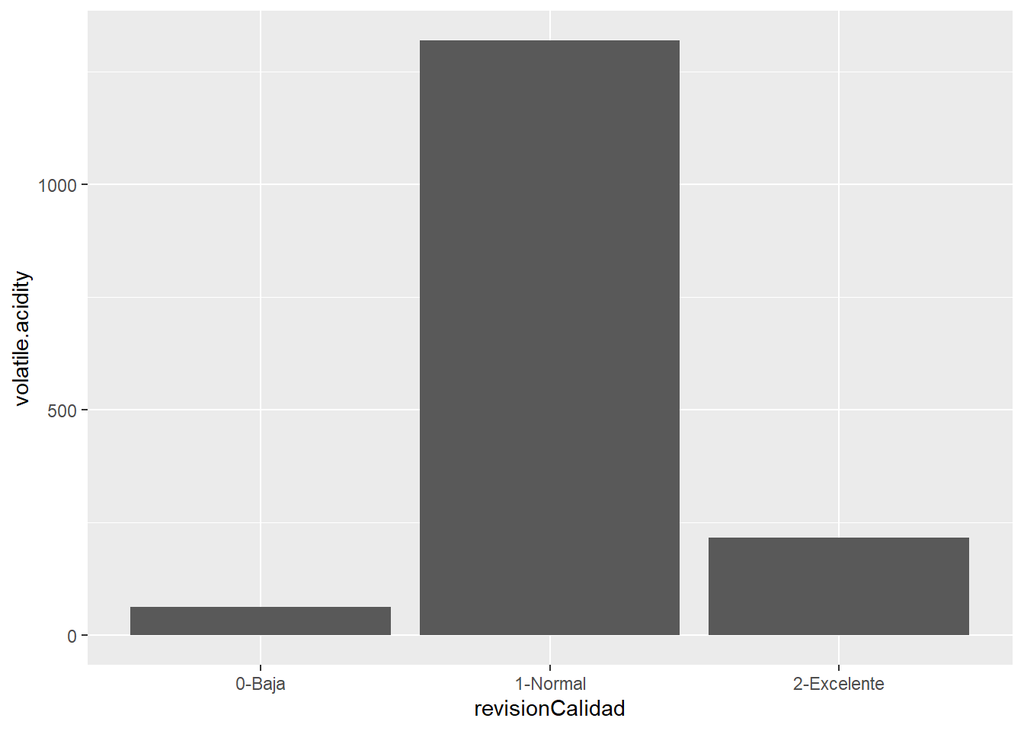

```r
ggplot(data = dataWine[1:filas,],aes(x=revisionCalidad,fill=volatile.acidity))+geom_bar()+ylab("volatile.acidity")
```

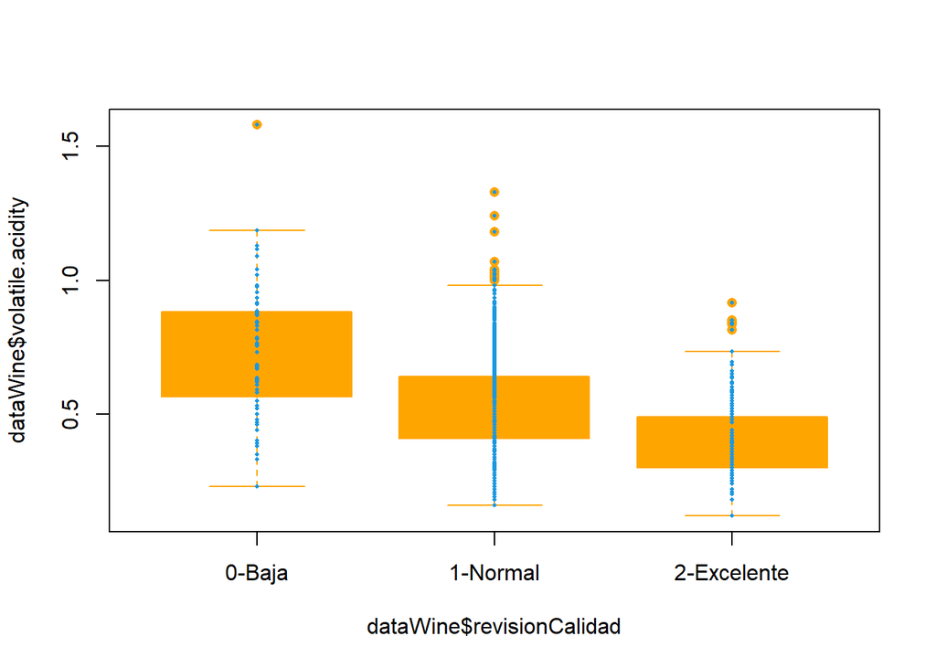

```r
boxplot(dataWine$volatile.acidity ~ dataWine$revisionCalidad,
        col = "orange",
        border = "orange",
        pch = 16)

points(dataWine$revisionCalidad, dataWine$volatile.acidity,
       col = "#1b98e0",
       pch = 16,
       cex = 0.4)
```

```r
#Atributo citric.acid
print("Distribución de citric.acid")
```

```
## [1] "Distribución de citric.acid"
```

```r
summary(dataWine$citric.acid)
```

```
##    Min. 1st Qu.  Median    Mean 3rd Qu.    Max.
##   0.000   0.090   0.260   0.271   0.420   1.000
```

```r
table(sort(dataWine$citric.acid))
```

```
##
##    0 0.01 0.02 0.03 0.04 0.05 0.06 0.07 0.08 0.09  0.1 0.11 0.12 0.13 0.14 0.15
##  132   33   50   30   29   20   24   22   33   30   35   15   27   18   21   19
## 0.16 0.17 0.18 0.19  0.2 0.21 0.22 0.23 0.24 0.25 0.26 0.27 0.28 0.29  0.3 0.31
##    9   16   22   21   25   33   27   25   51   27   38   20   19   21   30   30
## 0.32 0.33 0.34 0.35 0.36 0.37 0.38 0.39  0.4 0.41 0.42 0.43 0.44 0.45 0.46 0.47
##   32   25   24   13   20   19   14   28   29   16   29   15   23   22   19   18
## 0.48 0.49  0.5 0.51 0.52 0.53 0.54 0.55 0.56 0.57 0.58 0.59  0.6 0.61 0.62 0.63
##   23   68   20   13   17   14   13   12    8    9    9    8    9    2    1   10
## 0.64 0.65 0.66 0.67 0.68 0.69  0.7 0.71 0.72 0.73 0.74 0.75 0.76 0.78 0.79    1
##    9    7   14    2   11    4    2    1    1    3    4    1    3    1    1    1
```

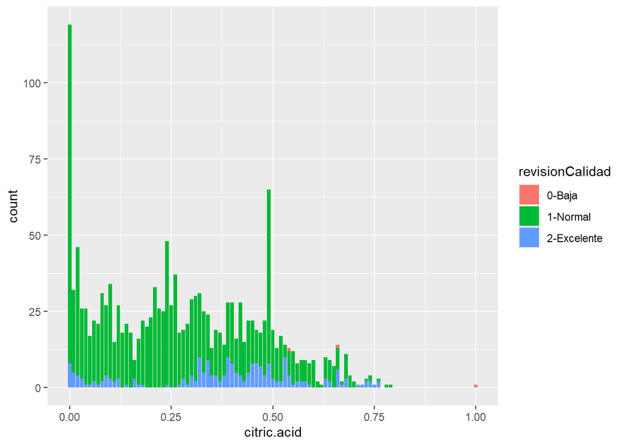

```r
ggplot(data = dataWine[1:filas,],aes(x=citric.acid,fill=revisionCalidad))+geom_bar()
```